# Das Beispiel SAT Scores aus McClave-Benson

Manfred Brill

Sommersemester 2021

# 1 Motivation

Wir haben bereits Hypothesentests durchgeführt, mit denen wir zwei Stichproben darauf überprüfen können, ob die beiden Erwartungswerte gleich sind oder nicht. Dazu haben wir einen t-Test durchgeführt. Wir betrachten ein weiteres Beispiel für den Einsatz solcher unverbunderen t-Tests und führen anschließend die Variationsanalyse oder kurz ANOVA (*analysis of variance*) ein. Wir erhalten bei unseren Hypothesentests die gleichen Ergebnisse. Der Vorteil der Variationsanalyse ist jedoch, dass wir diesen Ansatz auf mehr als zwei Einflussgrößen oder Level in einem Datensatz anwenden können.

# 2 Unverbundene t-Tests

Wir wiederholen nochmals den Einsatz von t-Tests und gehen am Ende zu einer Funktion in R über, die das gleiche Experiment an Hand eines Hypothesentests untersucht und dafür ANOVA verwendet.

Die Daten die wir in diesem Abschnitt verwenden stammen aus (McClave and Benson 1991). Wir untersuchen die SAT scores, die Prüfungsergebnisse von potentiellen Studierenden an einer amerikanischen Hochschule. Dazu gibt das Buch insgesamt 10 Daten an, jeweils 5 Daten von Frauen und 5 von Männern. Die Daten gibt es zweimal, wobei bei jeder Variante die Mittelwerte der Daten gleich sind und sich je nach Geschlecht unterscheiden. Die Frage ist natürlich ob wir mit einem t-Test oder ANOVA entscheiden können ob die Nullhypothese, dass die Erwartungswerte für beide Level gleich sind, verworfen wird oder nicht.

## 2.1 Die Daten

Die Daten für dieses Beispiel werden nicht aus einer Datei eingelesen sondern wurden auf dem Buch entnommen und in Datensätze in R überführt. Die Daten werden als tibble abgelegt. Das Geschlecht wird als *factor* in einer weiteren Spalte abgelegt. Tabelle 1 zeigt den Inhalt dieses Datensatzes.

Tabelle 1: Die Prüfungsergebnisse als tibble

| Punktzahl | Geschlecht |
| --- | --- |
| 490 | w |
| 520 | w |
| 550 | w |
| 580 | w |
| 610 | w |
| 530 | m |
| 560 | m |
| 590 | m |
| 620 | m |
| 650 | m |

Wir berechnen mit Hilfe der Funktion *summarize* den Mittelwert und die Standardabweichung:

```r
agg1 <- satscores1 %>%
  group_by(treatment) %>%
  summarize(Mittelwerte=mean(response),
            Standardabweichungen=sd(response),
            .groups="keep")
```

Für die Mittelwerte erhalten wir die Werte 590 für die männlichen und 550 für die weiblichen Teilnehmer. Die Standardabweichungen für beide Teile der Ergebnisse stimmen überein, wir erhalten jeweils den Wert 47.4342.

Als Alternative wird im Buch ein weiterer Datensatz vorgestellt, die wir genauso repräsentieren. In Tabelle 2 sind diese Daten zu sehen.

Tabelle 2: Die alternativen Prüfungsergebnisse als tibble

| Punktzahl | Geschlecht |
| --- | --- |
| 540 | w |
| 545 | w |
| 550 | w |
| 555 | w |
| 560 | w |
| 580 | m |
| 585 | m |
| 590 | m |
| 595 | m |
| 600 | m |

Für die Mittelwerte erhalten wir die gleichen Werte wie für die erste Alternative: 590 für die männlichen und 550 für die weiblichen Teilnehmer. Wieder stimmen die Standardabweichungen für beide Teile der Ergebnisse überein, wir erhalten jeweils den Wert 7.9057.

## 2.2 Visualisierungen

Wir visualisieren jetzt beide Datensätze um uns einen Eindruck zu beschaffen, ob die Nullhypothese in den anschließenden Hypothesentests verworfen werden kann oder nicht. Dazu stellen die Werte als Punkte auf dem Zahlenstrahl aus.

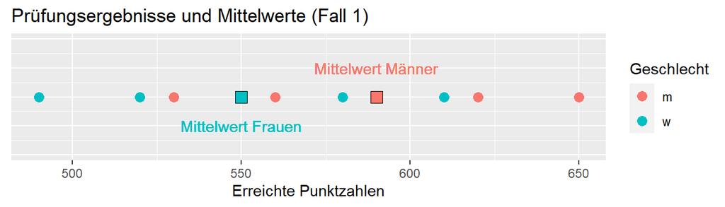

Die Punkte liegen ineinander verschränkt, die Mittelwerte deuten aber auf unterschiedliche Werte hin. Davon können wir uns gut mit Hilfe eines Box-Plots überzeugen.

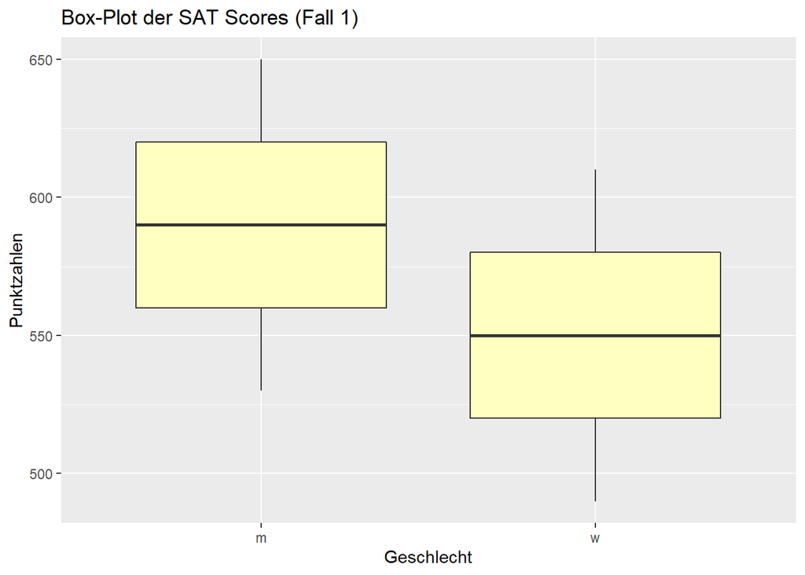

Als Alternative verwenden wir die Funktion *plotmeans* aus der Package *car*. Damit erhalten wir eine Ausgabe der Mittelwerte und für jeden Wert des verwendeten Faktors ein Konfidenzintervall. Wir verwenden hier den Defaultwert von 95% des Konfidenzniveaus. Die beiden Konfidenzintervalle schneiden sich, was darauf hinweist, dass beim anschließenden Hypothesentest nicht unbedingt zu erwarten ist, dass die Nullhypothese verworfen wird.

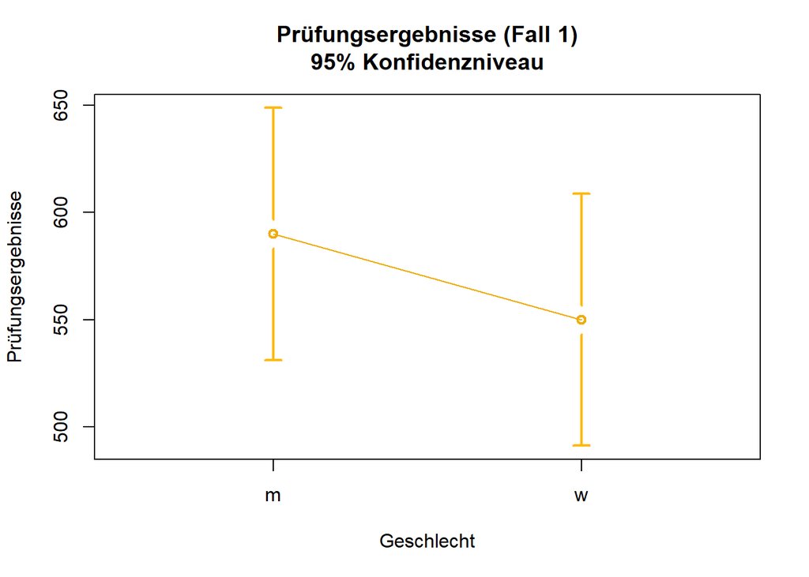

Jetzt visualisieren wir mit den gleichen Funktionen den zweiten Fall:

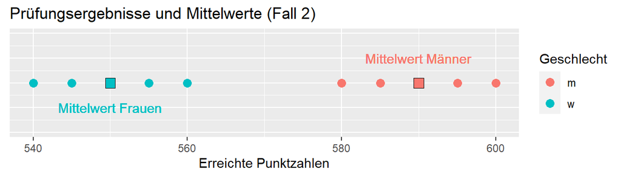

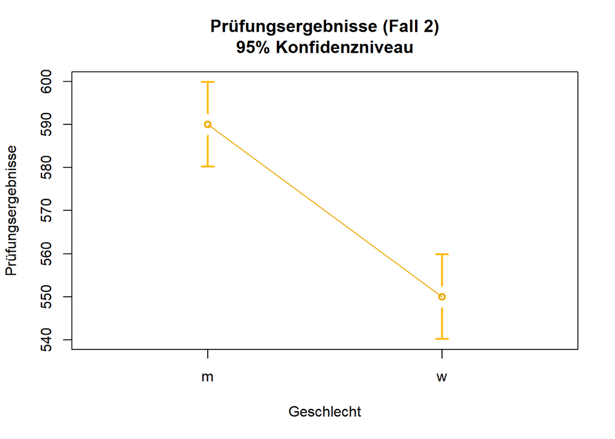

In diesem Fall sehen wir, dass die Ergebnisse klar voneinander getrennt sind. Das ist in beiden Abbildungen gut zu erkennen. Hier würden wir erwarten, dass die Nullhypothese in den Tests verworfen wird. Es ist auch gut zu sehen dass im Fall 2 die Streuung in den Ergebnisse kleiner ist. Davon hatten wir uns bereits mit Hilfe der Standardabweichungen überzeugt.

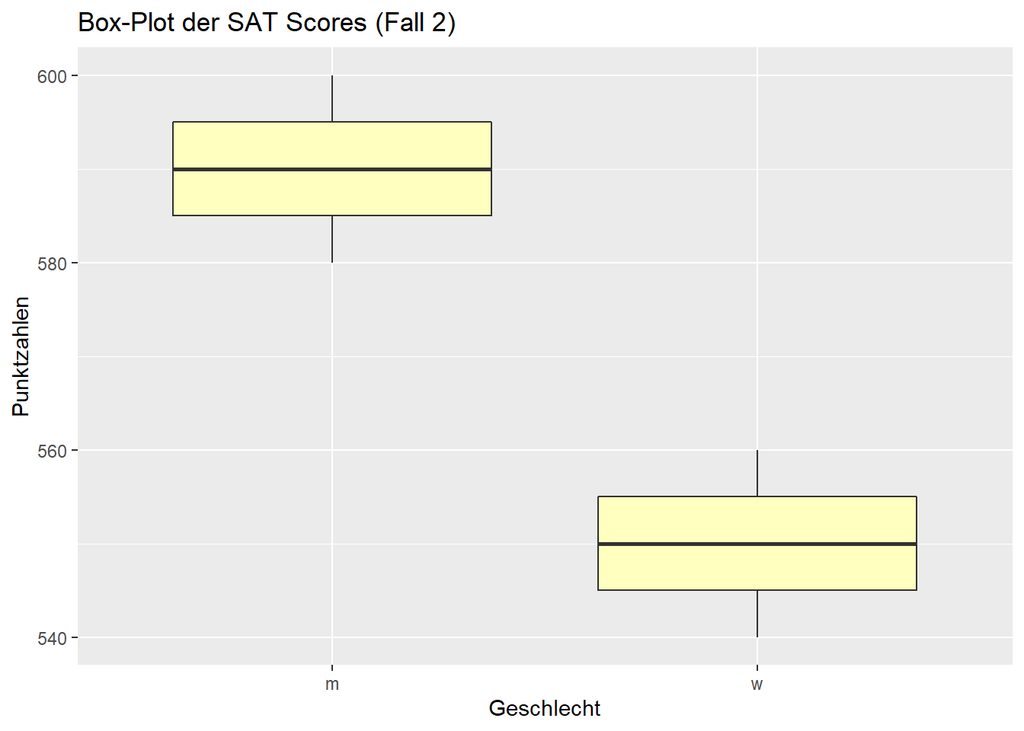

## 2.3 Hypothesentests

Wir führen jetzt die Hypothesentests durch. Dazu verwenden wir wieder die Funktion *t.test*. Wir gehen davon aus, dass die Varianzen in beiden Teilen übereinstimmen. Das Ergebnis, das wir erhalten wird durch diese Einstellung nicht wesentlich beeinflusst, wovon Sie sich gerne überzeugen können. Aber wir hatten bei der Untersuchung der Streuung festgestellt, dass die Standardabweichungen in beiden Teilen der Teilnehmer überein gestimmt hatten.

Wir beginnen mit dem Fall 1:

```r
t.test(response~treatment, data=satscores1,
                 paired=FALSE,
                 alternative="two.sided",
                 var.equal=TRUE)
```

```
##
##  Two Sample t-test
##
## data:  response by treatment
## t = 1.3, df = 8, p-value = 0.2
## alternative hypothesis: true difference in means is not equal to 0
## 95 percent confidence interval:
##  -29.18 109.18
## sample estimates:
## mean in group m mean in group w
##             590             550
```

Auf Grund dieser Ergebnisse verwerfen wir für diese Daten die Nullhypothese, dass die Erwartungswerte bei Frauen und Männer gleich sind, nicht. Das hatten wir bereits an Hand der Visualisierungen vermutet.

Wir betrachten jetzt den Fall 2. Hier würden wir erwarten, dass die Nullhypothese verworfen wird:

```r
t.test(response~treatment, data=satscores2,
                 paired=FALSE,
                 alternative="two.sided",
                 var.equal=TRUE)
```

```
##
##  Two Sample t-test
##
## data:  response by treatment
## t = 8, df = 8, p-value = 4e-05
## alternative hypothesis: true difference in means is not equal to 0
## 95 percent confidence interval:
##  28.47 51.53
## sample estimates:
## mean in group m mean in group w
##             590             550
```

Die Ausgaben von R bestätigen diese Erwartung, wir verwerfen die Nullhypothese und gehen davon aus, dass sich die Erwartungswerte für die Punktzahlen bei Frauen und Männern unterscheiden.

# 3 Varianzanalyse - Analysis of Variance

Bei den bisherigen Betrachtungen stellen wir fest, dass wir auf der einen Seite die Varianz im kompletten Datensatz, unabhängig vom Geschlecht der Studierenden in Relation zur Varianz in den beiden Einzelteilen setzen müssen. Als Daten für die Darstellung verwenden wir den Fall 2 der SAT Scores.

Dazu berechnen wir zuerst die Streuung der Mittelwerte der beiden Teilmengen für das jeweilige Geschlecht um den Mittelwert des kompletten Datensatzes. Die beiden Mittelwerte sind durch 550 und 590 gegeben, der Mittelwert für die Spalte *response* ist durch 570 gegeben. Diese Summe von quadratischen Abweichungen nennen wir *SST* für *sum of squares for treatment*. Wir formulieren dies direkt allgemein für mehr als 2 Teile, als Symbol für die Anzahl der Teile verwenden wir p. Im Beispiel ist p=2, mit $\overline{y}$ bezeichnen wir den Mittelwert des Gesamtdatensatzes, mit $\overline{y}_i$ die der einzelnen Gruppen:
$$SST = \sum_{i=1}^p n_i(\overline{y}_i - \overline{y})^2$$
Dies berechnen wir jetzt für unser Beispiel:

```r
n1 <- 5
n2 <- 5
ybar<- 0.5*(agg2$Mittelwerte[1] + agg2$Mittelwerte[2])
sst <- n1*(agg2$Mittelwerte[1]-ybar)**2 + n2*(agg2$Mittelwerte[2]-ybar)**2
```

Für unser Beispiel erhalten wir den Wert SST = 4000.

Jetzt bilden wir eine weitere Quadratsumme, mit der wir die Streuung innerhalb der Gruppen messen. Wir nennen diese Summe *sum of squares for error* und kurz SSE. Wieder formulieren wir die Formel allgemein und setzen unsere konkreten Werten aus dem Fall 2 ein.
$$SSE = \sum_{j=1}^{n_1} (y_{1j} - \overline{y}_1)^2 + \ldots + \sum_{j=1}^{n_p} (y_{pj} - \overline{y}_p)^2$$
Für unser Beispiel ist dies leicht zu berechnen, da die ersten 5 Zeilen zu den Frauen und die restlichen5 Zeilen zu den männlichen Teilnehmern gehören:

```r
sse1 <- satscores2$response[1:5]
sse1 <- sse1 - agg2$Mittelwerte[2]
sse1Sum <- sum(sse1**2)

sse2 <- satscores2$response[6:10]
sse2 <- sse2 - agg2$Mittelwerte[1]
sse2Sum <- sum(sse1**2)

sse <- sse1Sum+sse2Sum
```

Wir erhalten das Ergebnis 500 für SSE. Jetzt müssen wir diese Quadratsummen noch durch die Anzahl der Freiheitsgrade dividieren, damit berechnen wir die Variablen *mean square for treatments* MST und *mean square for error* MSE:
$$MST = \frac{SST}{p-1}, MSE = \frac{SSE}{n-p}.$$

In unserem Beispiel ist p=2, damit erhalten wir für den Fall 2 die beiden Werte 4000 für MST und 62.5 für MSE.

Jetzt setzen wir diese beiden Quadratsummen in Relation zueinander und bilden den Quotienten
$$F = \frac{MST}{MSE}$$
Ist der Quotient F nahe beim Wert 1 weist dies darauf hin, dass die Streuung innerhalb der Gruppen und die Streuung im kompletten Datensatz sehr nahe beieinander liegen. Dann könnten die Unterschiede zwischen den verschiedenen Mittelwerte in den Gruppen einfach durch zufällige Einflüsse entstanden sein. Anders sieht es aus wenn der Quotient F weit von 1 entfernt ist. Dann ist die Streuung innerhalb der verschiedenen Gruppenmittelwerte deutlich größer als die Streuung innerhalb der Gruppen, was ja im Fall 2 durchaus der Fall ist. In unserem Beispiel erhalten wir in diesem Fall einen Wert von 64 für den Quotienten.

Ein Quotient von Quadratsummen wir F hat eine F-Verteilung. Also können wir damit wieder einen Hypothesentest durchführen und fragen uns, ob der Quotient weit genug von der 1 entfernt ist um die Nullhypothese zu verwerfen, dass die Erwartungswerte der Gruppen gleich sind.

Wir berechnen die Quantile der F-Verteilung. Dazu haben wir die Freiheitsgrade p-1 und für n-p in Zähler und Nenner. Dies sind die beiden Zahlen die wir bereits in der Berechnung von Zähler und Nenner verwendet haben. Wir berechnen das 95% Quantil:

```r
fquant <- qf(0.95, 1, 8)
```

Wir erhalten den Wert 5.3177 für dieses Quantil. Unser berechnet Wert liegt deutlich oberhalb dieses Quantils, so dass wir die Nullhypothese verwerfen, wie schon beim t-Test. Für den Fall 1 können wir alle Berechnungen analog durchführen. Hier ist der Quotient durch den Wert 1.78 gegeben. Wir verwerfen, wie schon beim t-Test, die Nullhypothese nicht.

# 4 ANOVA in R

In R gibt es für den eben vorgestellten hypothesentest die Funktion *aov*. Der Aufruf der Funktion *aov* ähnelt dem Aufruf der Funktion *lm*, mit der wir lineare Modelle und Regressionsgeraden berechnen können. Das ist kein Zufall und liegt an der zu Grunde liegenden Mathematik. Wir führen einen Hypothesentest für den Fall 1 aus, bei dem der t-Test die Nullhypothese nicht verworfen hatte. Wir speichern dabei die Ausgabe der Funktion *aov* in einem Objekt und verwenden die Funktion *summary*, um die Ergebnisse des Tests auszugeben.

```r
aovfit1 <- aov(response~treatment, data=satscores1)
summary(aovfit1)
```

```
##             Df Sum Sq Mean Sq F value Pr(>F)
## treatment    1   4000    4000    1.78   0.22
## Residuals    8  18000    2250
```

Der p-Wert, den wir in der ersten Zeile der Ausgabe als letzten Wert finden, führt dazu, dass wir die Nullhypothese nicht verwerfen. Im Eintrag *F value* finden wir den wert des Quotienten wieder, den wir in der Herleitung manuell berechnet hatten.

Welches Ergebnis erhalten wir für den Fall 2?

```r
aovfit2 <- aov(response~treatment, data=satscores2)
summary(aovfit2)
```

```
##             Df Sum Sq Mean Sq F value  Pr(>F)
## treatment    1   4000    4000      64 4.4e-05 ***
## Residuals    8    500      63
## ---
## Signif. codes:  0 '***' 0.001 '**' 0.01 '*' 0.05 '.' 0.1 ' ' 1
```

Wie schon selbst berechnet ist der *F value* durch 64 gegeben. Wieder wird die Nullhypothese verworfen, dafür spricht auch der angegebene p-Wert.

Im Fall von zwei Stufen einer Einflussgröße können wir sowohl die Funktion *t.test* oder die Funktion *aov* einsetzen. Das statistische Ergebnis der Tests ist das gleiche.

# Literaturverzeichnis

McClave, James, and George Benson. 1991. *Statistics for Business and Economics*. McMillan.